## Project Description

- To define whether crimes rates are related to the income levels or not, generating ideas for avert these crimes if it is.

## Project goal & social problem addressed

- Show that there is a relationship between the income levels and crime rates.The social problem in this project is the low income distribution and the high crime rate. As a result of this project, it is important to prevent crimes and increase income level.

```r
library(tidyverse)
options(warn=-1)
```

## Project data

*Crime:

1. Homicide rates
2. Sexual abuse and rape rates

*Economy:

1. GDP rates
2. Employment
3. Gini index

Variables in crime: Year, gender, cause, countries, location etc.

Variables in economy: Work hours, countries, GDP, Inequality Index etc.

## Dataset Analyzing

First of all, data on the subject were collected. Then, unnecessary data from these data were eliminated.Detailed information about dataset analyzing was given in the interim report.

- The datasets about crime rates are:
- Murders2005
- Murders2006
- Murders2007
- Murders2008
- Murders2009
- Murders2010
- Rapes2005
- Rapes2006
- Rapes2007
- Rapes2008
- Rapes2009
- Rapes2010

## Importing datasets about income levels and renaming them

```r
employment <- read.csv("datasets/ANHRS_31102021130035527.csv")
gpd <- read.csv("datasets/API_NY.GDP.MKTP.CD_DS2_en_csv_v2_3158872.csv")
gini <- read.csv("datasets/API_SI.POV.GINI_DS2_en_csv_v2_3158890.csv")
homicide <- read.csv("datasets/API_VC.IHR.PSRC.P5_DS2_en_csv_v2_3161002.csv")
sexualviolence <- read.csv("datasets/cts_sexual_violence_2012.csv")
```

## Dataframes

```r
head(employment,5)
```

```
##   ï..COUNTRY   Country EMPSTAT Employment.status FREQUENCY Frequency TIME Time
## 1        AUS Australia      TE  Total employment         A    Annual 2010 2010
## 2        AUS Australia      TE  Total employment         A    Annual 2011 2011
## 3        AUS Australia      TE  Total employment         A    Annual 2012 2012
## 4        AUS Australia      TE  Total employment         A    Annual 2013 2013
## 5        AUS Australia      TE  Total employment         A    Annual 2014 2014
##   Unit.Code  Unit PowerCode.Code PowerCode Reference.Period.Code
## 1      HOUR Hours              0     Units                    NA
## 2      HOUR Hours              0     Units                    NA
## 3      HOUR Hours              0     Units                    NA
## 4      HOUR Hours              0     Units                    NA
## 5      HOUR Hours              0     Units                    NA
##   Reference.Period Value Flag.Codes Flags
## 1               NA  1778         NA    NA
## 2               NA  1774         NA    NA
## 3               NA  1771         NA    NA
## 4               NA  1766         NA    NA
## 5               NA  1755         NA    NA
```

```r
head(gpd,5)
```

```
##      ï..Data.Source World.Development.Indicators           Column1
## 1
## 2 Last Updated Date                   2021-10-28
## 3
## 4      Country Name                 Country Code    Indicator Name
## 5             Aruba                          ABW GDP (current US$)
##              X_1  X_2  X_3  X_4  X_5  X_6  X_7  X_8  X_9 X_10 X_11 X_12 X_13
## 1                  NA   NA   NA   NA   NA   NA   NA   NA   NA   NA   NA   NA
## 2                  NA   NA   NA   NA   NA   NA   NA   NA   NA   NA   NA   NA
## 3                  NA   NA   NA   NA   NA   NA   NA   NA   NA   NA   NA   NA
## 4 Indicator Code 1960 1961 1962 1963 1964 1965 1966 1967 1968 1969 1970 1971
## 5 NY.GDP.MKTP.CD   NA   NA   NA   NA   NA   NA   NA   NA   NA   NA   NA   NA
##   X_14 X_15 X_16 X_17 X_18 X_19 X_20 X_21 X_22 X_23 X_24 X_25 X_26 X_27
## 1   NA   NA   NA   NA   NA   NA   NA   NA   NA   NA   NA   NA   NA   NA
## 2   NA   NA   NA   NA   NA   NA   NA   NA   NA   NA   NA   NA   NA   NA
```

[output cut: 33 more lines]

```r
head(gini,5)
```

```
##      ï..Data.Source World.Development.Indicators
## 1
## 2 Last Updated Date                   2021-10-28
## 3
## 4      Country Name                 Country Code
## 5             Aruba                          ABW
##                            Column1            X_1  X_2  X_3  X_4  X_5  X_6  X_7
## 1                                                   NA   NA   NA   NA   NA   NA
## 2                                                   NA   NA   NA   NA   NA   NA
## 3                                                   NA   NA   NA   NA   NA   NA
## 4                   Indicator Name Indicator Code 1960 1961 1962 1963 1964 1965
## 5 Gini index (World Bank estimate)    SI.POV.GINI   NA   NA   NA   NA   NA   NA
##    X_8  X_9 X_10 X_11 X_12 X_13 X_14 X_15 X_16 X_17 X_18 X_19 X_20 X_21 X_22
## 1   NA   NA   NA   NA   NA   NA   NA   NA   NA   NA   NA   NA   NA   NA   NA
## 2   NA   NA   NA   NA   NA   NA   NA   NA   NA   NA   NA   NA   NA   NA   NA
```

[output cut: 21 more lines]

```r
head(homicide,5)
```

```
##      ï..Data.Source World.Development.Indicators
## 1
## 2 Last Updated Date                   2021-10-28
## 3
## 4      Country Name                 Country Code
## 5             Aruba                          ABW
##                                      Column1            X_1  X_2  X_3  X_4  X_5
## 1                                                             NA   NA   NA   NA
## 2                                                             NA   NA   NA   NA
## 3                                                             NA   NA   NA   NA
## 4                             Indicator Name Indicator Code 1960 1961 1962 1963
## 5 Intentional homicides (per 100,000 people) VC.IHR.PSRC.P5   NA   NA   NA   NA
##    X_6  X_7  X_8  X_9 X_10 X_11 X_12 X_13 X_14 X_15 X_16 X_17 X_18 X_19 X_20
## 1   NA   NA   NA   NA   NA   NA   NA   NA   NA   NA   NA   NA   NA   NA   NA
## 2   NA   NA   NA   NA   NA   NA   NA   NA   NA   NA   NA   NA   NA   NA   NA
```

[output cut: 33 more lines]

```r
head(sexualviolence,5)
```

```
##   country.territory  date sexual.violence        rate
## 1     #country+name #date       #affected  #meta+rate
## 2           Albania  2003            <NA>        <NA>
## 3           Albania  2004            <NA>        <NA>
## 4           Albania  2005              89 2.832771023
## 5           Albania  2006              87 2.756123901
```

- GPD, Gini and Homicide’s headers needs to be replaced with 4th row. Sexual violence’s first row needs to be deleted.

```r
names(gpd) <- as.matrix(gpd[4, ])
gpd <- gpd[-4, ]
gpd[] <- lapply(gpd, function(x) type.convert(as.character(x)))
gpd <- gpd[-1, ]
gpd <- gpd[-1, ]
gpd <- gpd[-1, ]
row.names(gpd) <- NULL
head(gpd)
```

```
##                  Country Name Country Code    Indicator Name Indicator Code
## 1                       Aruba          ABW GDP (current US$) NY.GDP.MKTP.CD
## 2 Africa Eastern and Southern          AFE GDP (current US$) NY.GDP.MKTP.CD
## 3                 Afghanistan          AFG GDP (current US$) NY.GDP.MKTP.CD
## 4  Africa Western and Central          AFW GDP (current US$) NY.GDP.MKTP.CD
## 5                      Angola          AGO GDP (current US$) NY.GDP.MKTP.CD
## 6                     Albania          ALB GDP (current US$) NY.GDP.MKTP.CD
##          1960        1961        1962        1963        1964        1965
## 1          NA          NA          NA          NA          NA          NA
## 2 19342484576 19753490586 21526615650 25772356399 23563232195 26851350246
## 3   537777811   548888896   546666678   751111191   800000044  1006666638
## 4 10407321640 11131302981 11946843969 12680220415 13842621612 14866816737
## 5          NA          NA          NA          NA          NA          NA
## 6          NA          NA          NA          NA          NA          NA
##          1966        1967        1968        1969        1970        1971
```

[output cut: 69 more lines]

```r
names(gini) <- as.matrix(gini[4, ])
gini <- gini[-4, ]
gini[] <- lapply(gini, function(x) type.convert(as.character(x)))
gini <- gini[-1, ]
gini <- gini[-1, ]
gini <- gini[-1, ]
row.names(gini) <- NULL
head(gini)
```

```
##                  Country Name Country Code                   Indicator Name
## 1                       Aruba          ABW Gini index (World Bank estimate)
## 2 Africa Eastern and Southern          AFE Gini index (World Bank estimate)
## 3                 Afghanistan          AFG Gini index (World Bank estimate)
## 4  Africa Western and Central          AFW Gini index (World Bank estimate)
## 5                      Angola          AGO Gini index (World Bank estimate)
## 6                     Albania          ALB Gini index (World Bank estimate)
##   Indicator Code 1960 1961 1962 1963 1964 1965 1966 1967 1968 1969 1970 1971
## 1    SI.POV.GINI   NA   NA   NA   NA   NA   NA   NA   NA   NA   NA   NA   NA
## 2    SI.POV.GINI   NA   NA   NA   NA   NA   NA   NA   NA   NA   NA   NA   NA
## 3    SI.POV.GINI   NA   NA   NA   NA   NA   NA   NA   NA   NA   NA   NA   NA
## 4    SI.POV.GINI   NA   NA   NA   NA   NA   NA   NA   NA   NA   NA   NA   NA
## 5    SI.POV.GINI   NA   NA   NA   NA   NA   NA   NA   NA   NA   NA   NA   NA
## 6    SI.POV.GINI   NA   NA   NA   NA   NA   NA   NA   NA   NA   NA   NA   NA
##   1972 1973 1974 1975 1976 1977 1978 1979 1980 1981 1982 1983 1984 1985 1986
```

[output cut: 27 more lines]

```r
names(homicide) <- as.matrix(homicide[4, ])
homicide <- homicide[-4, ]
homicide[] <- lapply(homicide, function(x) type.convert(as.character(x)))
homicide <- homicide[-1, ]
homicide <- homicide[-1, ]
homicide <- homicide[-1, ]
row.names(homicide) <- NULL
head(homicide)
```

```
##                  Country Name Country Code
## 1                       Aruba          ABW
## 2 Africa Eastern and Southern          AFE
## 3                 Afghanistan          AFG
## 4  Africa Western and Central          AFW
## 5                      Angola          AGO
## 6                     Albania          ALB
##                               Indicator Name Indicator Code 1960 1961 1962 1963
## 1 Intentional homicides (per 100,000 people) VC.IHR.PSRC.P5   NA   NA   NA   NA
## 2 Intentional homicides (per 100,000 people) VC.IHR.PSRC.P5   NA   NA   NA   NA
## 3 Intentional homicides (per 100,000 people) VC.IHR.PSRC.P5   NA   NA   NA   NA
## 4 Intentional homicides (per 100,000 people) VC.IHR.PSRC.P5   NA   NA   NA   NA
## 5 Intentional homicides (per 100,000 people) VC.IHR.PSRC.P5   NA   NA   NA   NA
## 6 Intentional homicides (per 100,000 people) VC.IHR.PSRC.P5   NA   NA   NA   NA
##   1964 1965 1966 1967 1968 1969 1970 1971 1972 1973 1974 1975 1976 1977 1978
```

[output cut: 41 more lines]

```r
sexualviolence <- sexualviolence[-1, ]
head(sexualviolence)
```

```
##   country.territory date sexual.violence        rate
## 2           Albania 2003            <NA>        <NA>
## 3           Albania 2004            <NA>        <NA>
## 4           Albania 2005              89 2.832771023
## 5           Albania 2006              87 2.756123901
## 6           Albania 2007             101 3.186456613
## 7           Albania 2008              76 2.388887649
```

## Importing datasets about crime rates and renaming them

```r
Murders2005 <- read.csv("data/Murders2005.csv")
Murders2006 <- read.csv("data/Murders2006.csv")
Murders2007 <- read.csv("data/Murders2007.csv")
Murders2008 <- read.csv("data/Murders2008.csv")
Murders2009 <- read.csv("data/Murders2009.csv")
Murders2010 <- read.csv("data/Murders2010.csv")

Rapes2005 <- read.csv("data/Rapes2005.csv")
Rapes2006 <- read.csv("data/Rapes2006.csv")
Rapes2007 <- read.csv("data/Rapes2007.csv")
Rapes2008 <- read.csv("data/Rapes2008.csv")
Rapes2009 <- read.csv("data\\Rapes2009.csv")
Rapes2010 <- read.csv("data/Rapes2010.csv")
```

## Jointing datasets by using merge function

```r
df05= merge(x = Murders2005, y = Rapes2005, by = "Country")
head(df05)
```

```
##      Country Amount.x Date.x Amount.y Date.y
## 1    Albania      131   2005       49   2005
## 2  Argentina    2,115   2005    3,154   2005
## 3    Armenia       58   2005       15   2005
## 4    Austria       54   2005      678   2005
## 5    Bahrain        4   2005       25   2005
## 6 Bangladesh    3,592   2005   11,291   2005
```

```r
df06= merge(x = Murders2006, y = Rapes2006, by = "Country")
head(df06)
```

```
##      Country Amount.x Date.x Amount.y Date.y
## 1    Albania       87   2006       40   2006
## 2  Argentina    2,052   2006    3,264   2006
## 3    Armenia       79   2006        7   2006
## 4    Austria       61   2006      700   2006
## 5    Bahrain        7   2006       17   2006
## 6 Bangladesh    4,166   2006   11,682   2006
```

```r
df07= merge(x = Murders2007, y = Rapes2007, by = "Country")
head(df07)
```

```
##      Country Amount.x Date.x Amount.y Date.y
## 1    Albania      105   2007       41   2007
## 2    Algeria      438   2007      836   2007
## 3  Argentina    2,071   2007    3,276   2007
## 4    Armenia       77   2007        5   2007
## 5    Austria       45   2007      710   2007
## 6 Azerbaijan      189   2007       34   2007
```

```r
df08= merge(x = Murders2008, y = Rapes2008, by = "Country")
head(df08)
```

```
##     Country Amount.x Date.x Amount.y Date.y
## 1   Albania       93   2008       39   2008
## 2   Algeria      516   2008      812   2008
## 3 Argentina    2,305   2008    3,367   2008
## 4   Armenia       83   2008       15   2008
## 5 Australia      261   2008    6,382   2008
## 6   Austria       45   2008      693   2008
```

```r
df09= merge(x = Murders2009, y = Rapes2009, by = "Country")
head(df09)
```

```
##     Country Amount.x Date.x Amount.y Date.y
## 1   Albania       85   2009       34   2009
## 2   Armenia       83   2009       15   2009
## 3 Australia      263   2009    6,343   2009
## 4   Austria       43   2009      779   2009
## 5  Barbados       19   2009       68   2009
## 6   Belarus      473   2009      218   2009
```

```r
df10= merge(x = Murders2010, y = Rapes2010, by = "Country")
head(df10)
```

```
##      Country Amount.x Date.x Amount.y Date.y
## 1    Albania      127   2010       24   2010
## 2    Armenia       44   2010       11   2010
## 3  Australia      229   2010    6,378   2010
## 4    Austria       53   2010      875   2010
## 5 Azerbaijan      206   2010       16   2010
## 6    Belgium      180   2010    2,991   2010
```

## Changing the column names and removing the year

```r
MR2005<-subset(df05, select=-c(Date.x,Date.y))
MR2006<-subset(df06, select=-c(Date.x,Date.y))
MR2007<-subset(df07, select=-c(Date.x,Date.y))
MR2008<-subset(df08, select=-c(Date.x,Date.y))
MR2009<-subset(df09, select=-c(Date.x,Date.y))
MR2010<-subset(df10, select=-c(Date.x,Date.y))
MR0506<-merge(MR2005,MR2006,by='Country')
MR0708<-merge(MR2007,MR2008,by='Country')
MR0910<-merge(MR2009,MR2010,by='Country')
MR1<-merge(MR0506,MR0708,by='Country')
MR<-merge(MR1,MR0910,by='Country')
MR<-rename(MR, Murders2005=Amount.x.x.x, Rape2005=Amount.y.x.x,
       Murders2006=Amount.x.y.x, Rape2006=Amount.y.y.x,
       Murders2007=Amount.x.x.y, Rape2007=Amount.y.x.y,
       Murders2008=Amount.x.y.y, Rape2008=Amount.y.y.y,
       Murders2009=Amount.x.x, Rape2009=Amount.y.x,
       Murders2010=Amount.x.y, Rape2010=Amount.y.y)
```

## The final results

```r
head(MR)
```

```
##                  Country Murders2005 Rape2005 Murders2006 Rape2006 Murders2007
## 1                Albania         131       49          87       40         105
## 2                Armenia          58       15          79        7          77
## 3                Austria          54      678          61      700          45
## 4                Belgium         221    3,029         221    3,194         211
## 5                Bolivia         596    1,137         530    1,137         723
## 6 Bosnia and Herzegovina          70       39          73       40          66
##   Rape2007 Murders2008 Rape2008 Murders2009 Rape2009 Murders2010 Rape2010
## 1       41          93       39          85       34         127       24
## 2        5          83       15          83       15          44       11
## 3      710          45      693          43      779          53      875
## 4    3,232         200    3,126         186    2,953         180    2,991
## 5    1,437         724    1,596         673    1,989         884    2,587
## 6       44          66       35          67       29          56       46
```

- The economical data

```r
employmentcopy<-employment
employmentcopy<-filter(employment, Employment.status == 'Total employment')
EMP<-subset(employmentcopy, select=c(Country,Time,Value))
EMP2010 <- filter(EMP, Time == 2010)
EMP2010<-subset(EMP2010, select=-c(Time))
EMP2010<-rename(EMP2010, Unemployment2010=Value)

GPD2005<-data.frame(gpd[, c(1,50)])
GPD2005<-rename(GPD2005, Country=Country.Name, GPD2005=X2005)
```

```r
MR0510<-subset(MR, select=c(Country,Murders2005,Rape2005,Murders2010,Rape2010))
head(MR0510)
```

```
##                  Country Murders2005 Rape2005 Murders2010 Rape2010
## 1                Albania         131       49         127       24
## 2                Armenia          58       15          44       11
## 3                Austria          54      678          53      875
## 4                Belgium         221    3,029         180    2,991
## 5                Bolivia         596    1,137         884    2,587
## 6 Bosnia and Herzegovina          70       39          56       46
```

## Merging with the economical values

- This is the final data frame to make analyzes from.

```r
prefinal<-merge(EMP2010,MR0510, by='Country')
FINAL<-merge(prefinal,GPD2005, by='Country')
head(FINAL)
```

```
##   Country Unemployment2010 Murders2005 Rape2005 Murders2010 Rape2010
## 1 Austria           1552.0          54      678          53      875
## 2 Belgium           1574.0         221    3,029         180    2,991
## 3  Canada           1715.0         663      565         554      576
## 4 Estonia           1785.0         113      179          70       81
## 5 Finland           1585.0         119      593         118      818
## 6 Germany           1425.7         869    8,133         690    7,724
##        GPD2005
## 1 3.159740e+11
## 2 3.855710e+11
## 3 1.173110e+12
## 4 1.410679e+10
## 5 2.048090e+11
## 6 2.845800e+12
```

Before continuing, checking the types of data stored in FINAL

```r
sapply(FINAL, mode)
```

```
##          Country Unemployment2010      Murders2005         Rape2005
##      "character"        "numeric"      "character"      "character"
##      Murders2010         Rape2010          GPD2005
##      "character"      "character"        "numeric"
```

## Converting characters to numerical values

```r
cols.num <- c("Murders2005","Rape2005","Murders2010","Rape2010")
FINAL[cols.num] <- sapply(FINAL[cols.num],as.numeric)
sapply(FINAL, mode)
```

```
##          Country Unemployment2010      Murders2005         Rape2005
##      "character"        "numeric"        "numeric"        "numeric"
##      Murders2010         Rape2010          GPD2005
##        "numeric"        "numeric"        "numeric"
```

- Result Although the data is concentrated in a certain region, a positive correlation is observed between murder counts and GPD. That is, as the number of murders increases, so does the GPD.

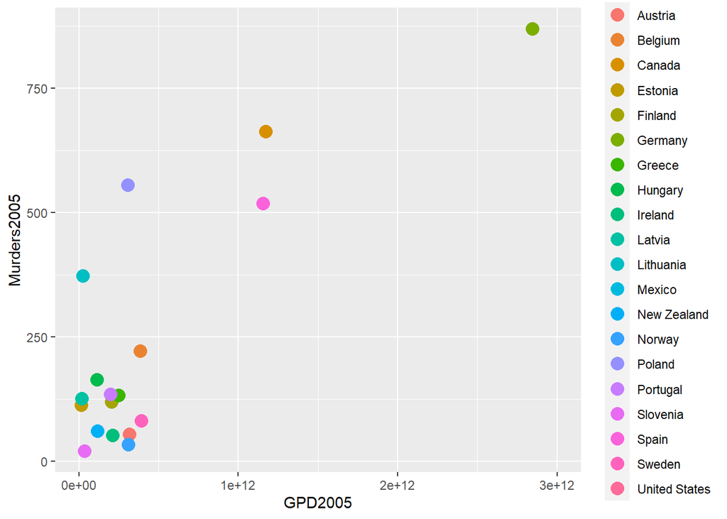

```r
ggplot(FINAL, aes(x=GPD2005, y=Murders2005, color=Country)) +
    geom_point(size=4) + xlim(0, 3*10^12)
```

## Graphing 2

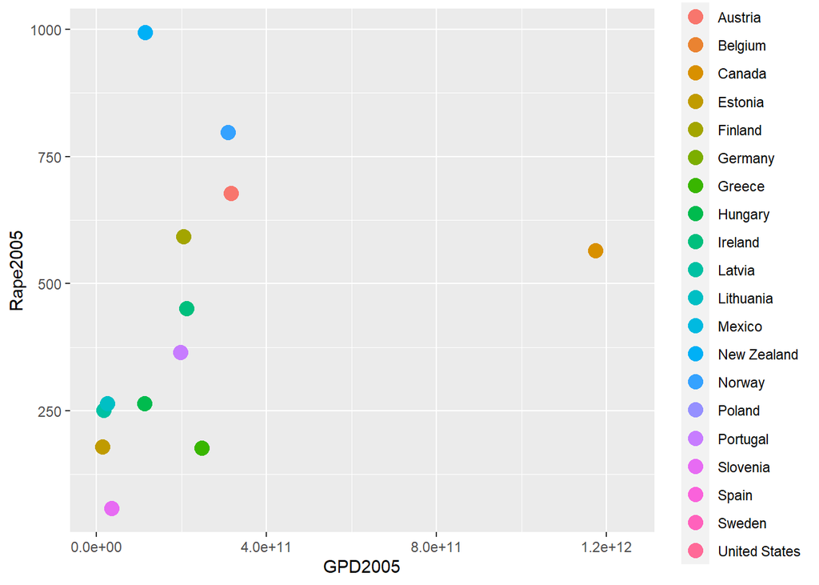

```r
ggplot(FINAL, aes(x=GPD2005, y=Rape2005, color=Country)) +
    geom_point(size=4) + xlim(0, 125*10^10)
```

## Graphing 3

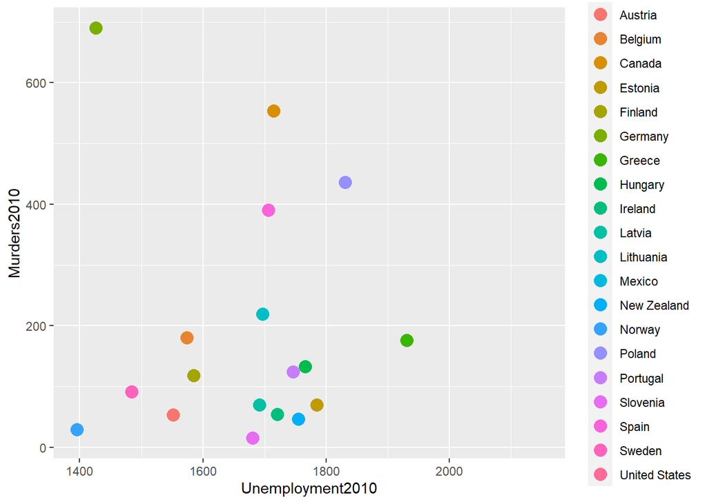

```r
ggplot(FINAL, aes(x=Unemployment2010, y=Murders2010, color=Country)) +
    geom_point(size=4)
```

## Graphing 4

- Result Unlike other graphs, there is no positive correlation in this graph. The employment rate increases as the rape rate decreases.

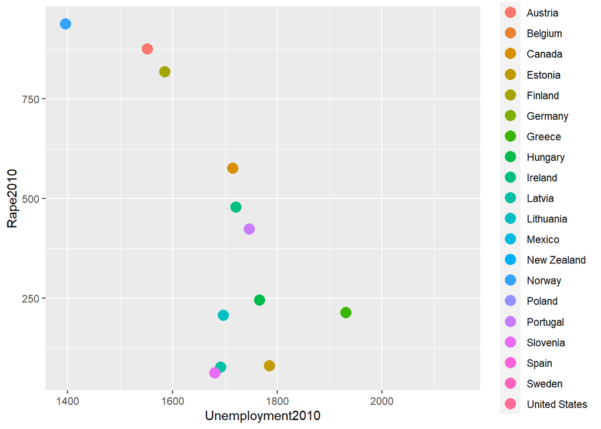

```r
ggplot(FINAL, aes(x=Unemployment2010, y=Rape2010, color=Country)) +
    geom_point(size=4)
```

## References.

- https://www.numbeo.com/crime/rankings_by_country.jsp?region=150&title=2019
- https://data.worldbank.org/indicator/SI.POV.GINI
- https://microdata.worldbank.org/index.php/catalog/1790/get-microdata